# Untitled

RN7

February 24, 2018

## Bullet Charts for Monitoring KPIs

This is the repo for the article found here on creating bullet charts for monitoring KPIs over time. The article mainly focused on `M&E` deliverables, or **“Indicators”**, but this post and repo will also come in handy for anyone that depends on Key Performance Indicators (KPI)s or those that need to track progress against a target.

Let’s look at the kind of data frame you would need to create the chart:

```r
glimpse(df)
```

```
## Observations: 6
## Variables: 11
## $ IndicatorName      <chr> "Ind 04", "Ind 05", "Ind 07", "Ind 11", "In...
## $ Actual             <dbl> 3, 437, 20, 44, 1, 10000
## $ Actual_lastWeek    <dbl> 3, 420, 18, 20, 1, 10000
## $ Actual_lastYear    <dbl> 3, 50, 20, 2000, 1, 10000
## $ Target             <dbl> 14, 81, 21, 10327, 5, 20000
## $ Perc               <dbl> 21.4285714, 100.0000000, 95.2380952, 0.4260...
## $ PercWeek           <dbl> 21.4285714, 100.0000000, 85.7142857, 0.1936...
## $ PercYear           <dbl> 21.42857, 61.72840, 95.23810, 19.36671, 20....
## $ BehindBy           <dbl> -8.104038, 0.000000, 0.000000, -8.104038, -...
## $ text               <chr> "Need 3 more", "OK!", "OK!", "Need 4141 mor...
## $ BehindFromLastWeek <dbl> 0, 17, 2, 24, 0, 0
```

As we can see…

The variables for the indicators/KPIs are as follows:

- `Actual`: the value of the indicator at the current time of viewing (“Today”)
- `Actual_lastWeek`: Last week’s value of the indicator
- `Actual_lastYear`: Last year’s value of the indicator
- `Target`: the target value for the indicator (used to calculate the percent variables)

Percentages are calculated by:

```r
## Take percents, but protecting against there being no targets
df$Perc <-     df$Actual/(df$Target + 0.0000000000001) * 100
df$PercWeek <- df$Actual_lastWeek/(df$Target + 0.0000000000001) * 100
df$PercYear <- df$Actual_lastYear/(df$Target + 0.0000000000001) * 100

## But truncate results if any are greater than 100
df$Perc[df$Perc > 100] <- 100
df$PercWeek[df$PercWeek > 100] <- 100
df$PercYear[df$PercYear > 100] <- 100
```

- `Perc`: Value of indicator as percent of yearly taget and percent of the year at the current time
- `PercWeek`: Last week’s value of the indicator as percent of yearly target and percent of the year
- `PercYear`: Last year’s value of the indicator as percent of yearly target and percent of the year

`BehindBy` is calculated by: `df$Perc - PercentTime` and shows how far behind the current value of the indicator is to the target value for the current time

The text can be shown by calculating:

```r
## Calculate how far behind TODAY (VALUE) for text, but remove NAs
df <- df %>%
  mutate(text = PercentTime/100 * df$Target - df$Actual)
df$text[df$BehindBy > 0] <-"OK!"
df$text[df$BehindBy <= 0 & !is.na(df$BehindBy)] <-
  paste("Need ", round(as.numeric(df$text[df$BehindBy <= 0  & !is.na(df$BehindBy)])), " more", sep = "")
```

- `text` = “OK!”: Shows that the current value of the indicator meets the target value for the current time
- `text` = “Need __ more”: Shows exactly how much more of the indicator is needed to reach the target value for the current time

Here’s one of the versions of the graph!

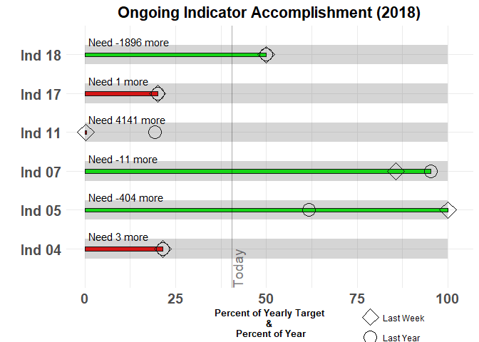

For something more similar to Stephen Few’s chart there is also this version:

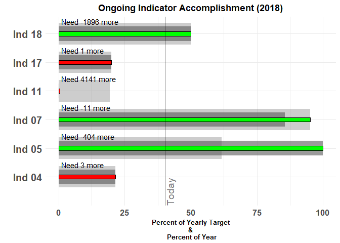